# Title:Analysing the effect of natural events on the public health and the country’s economy

#### Synopsis: In this study we aim to analyse the effects of natural events ,for instance,Hurrican,Flood,rain etc, on public health and economy.For this purpose we have obtained natural events related data from U.S. National Oceanic and Atmospheric Administration’s (NOAA) storm database.To analyse the effect on pulic health we take the data related to injuries and fatalities and to analyse the effect on economy we take the data related damaged property and crop.

### loading the data

```r
stormdata<-read.csv("repdata%2Fdata%2FStormData.csv.bz2",sep = ",")
```

### Processing the data

```r
damagedata<-stormdata[,c("EVTYPE","INJURIES","FATALITIES","PROPDMG","PROPDMGEXP","CROPDMG","CROPDMGEXP")]
```

### Required libraries

```r
library(plyr)
library(ggplot2)
```

#### total injuries due to each event

```r
totalinjury<-ddply(damagedata, .(EVTYPE),summarise,INJURIES=sum(INJURIES))
```

#### arranging the totalinjuries in decending order

```r
totalinjury<-totalinjury[order(totalinjury$INJURIES,decreasing = T),]
```

#### total fatalities due to each event

```r
totalfatality<-ddply(damagedata, .(EVTYPE),summarise,FATALITIES=sum(FATALITIES))
```

```r
totalfatality<-totalfatality[order(totalfatality$FATALITIES,decreasing = T),]
```

### creating a function to convert all the damage in dollers

```r
dol<-function(d){
  if(d%in%c("h","H")){
    return(100)
  }
  else if(d%in%c("K","k")){
    return(1000)
  }
  else if(d%in%c("m","M")){
    return(1000000)
  }
    else if(d%in%c("B","b")){
    return(1000000000)

}
  else{
    return(1)
  }

}
```

1.converting the expressions in power

```r
propertypower<-sapply(damagedata$PROPDMGEXP,dol)
croppower<-sapply(damagedata$CROPDMGEXP,dol)
```

2.converting the damages in doller

```r
damagedata$cropdollar<-damagedata$CROPDMG*croppower
damagedata$propertydollar<-damagedata$PROPDMG*propertypower
```

3.adding all the damaged property and crop dollars by the events

```r
finaldata<-ddply(damagedata, .(EVTYPE),summarise,damaged_property_in_dollars=sum(propertydollar),damaged_crop_in_dollars=sum(cropdollar))
```

4.ordering the damaged final data in decending order

```r
propfinaldata<-finaldata[order(finaldata$damaged_property_in_dollars,decreasing = T),]
cropfinaldata<-finaldata[order(finaldata$damaged_crop_in_dollars,decreasing = T),]
```

5.converting the dollars into billions

```r
propfinaldata$damaged_property_in_billions<-propfinaldata$damaged_property_in_dollars/1000000000
```

6.converting the dollors into millions

```r
cropfinaldata$damaged_crop_in_millions<-cropfinaldata$damaged_crop_in_dollars/1000000
```

## RESULT:

### Effect of events on population health

1.Most effective events on population health in terms of Injuries

```r
head(totalinjury,n=15)
```

```
##                EVTYPE INJURIES
## 834           TORNADO    91346
## 856         TSTM WIND     6957
## 170             FLOOD     6789
## 130    EXCESSIVE HEAT     6525
## 464         LIGHTNING     5230
## 275              HEAT     2100
## 427         ICE STORM     1975
## 153       FLASH FLOOD     1777
## 760 THUNDERSTORM WIND     1488
## 244              HAIL     1361
## 972      WINTER STORM     1321
## 411 HURRICANE/TYPHOON     1275
## 359         HIGH WIND     1137
## 310        HEAVY SNOW     1021
## 957          WILDFIRE      911
```

2.plotting the most effecctive events on the basis of injuries

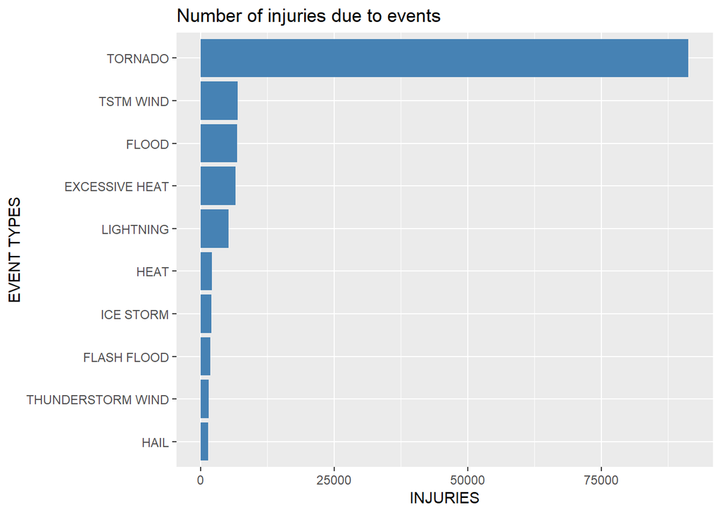

```r
ggplot(head(totalinjury,n=10),aes(x=reorder(EVTYPE,INJURIES),y=INJURIES))+geom_bar(fill="steelblue",stat="identity")+coord_flip()+ylab("INJURIES")+xlab("EVENT TYPES")+ggtitle("Number of injuries due to events")
```

3..Most effective events on population health in terms of fatalities

```r
head(totalfatality,n=15)
```

```
##                EVTYPE FATALITIES
## 834           TORNADO       5633
## 130    EXCESSIVE HEAT       1903
## 153       FLASH FLOOD        978
## 275              HEAT        937
## 464         LIGHTNING        816
## 856         TSTM WIND        504
## 170             FLOOD        470
## 585       RIP CURRENT        368
## 359         HIGH WIND        248
## 19          AVALANCHE        224
## 972      WINTER STORM        206
## 586      RIP CURRENTS        204
## 278         HEAT WAVE        172
## 140      EXTREME COLD        160
## 760 THUNDERSTORM WIND        133
```

4.plotting the most effecctive events on the basis of fatalities

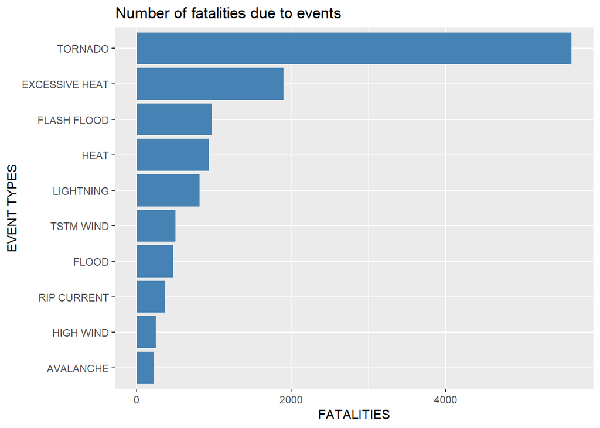

```r
ggplot(head(totalfatality,n=10),aes(x=reorder(EVTYPE,FATALITIES),y=FATALITIES))+geom_bar(fill="steelblue",stat="identity")+coord_flip()+ylab("FATALITIES")+xlab("EVENT TYPES")+ggtitle("Number of fatalities due to events")
```

## Economic consequences due to events

### property damage due to events

```r
head(propfinaldata,n=15)
```

```
##                EVTYPE damaged_property_in_dollars damaged_crop_in_dollars
## 170             FLOOD                144657709807              5661968450
## 411 HURRICANE/TYPHOON                 69305840000              2607872800
## 834           TORNADO                 56937160779               414953270
## 670       STORM SURGE                 43323536000                    5000
## 153       FLASH FLOOD                 16140812067              1421317100
## 244              HAIL                 15732267543              3025954473
## 402         HURRICANE                 11868319010              2741910000
## 848    TROPICAL STORM                  7703890550               678346000
## 972      WINTER STORM                  6688497251                26944000
## 359         HIGH WIND                  5270046295               638571300
## 590       RIVER FLOOD                  5118945500              5029459000
## 957          WILDFIRE                  4765114000               295472800
## 671  STORM SURGE/TIDE                  4641188000                  850000
## 856         TSTM WIND                  4484928495               554007350
```

[output cut: 17 more lines]

#### plotting the damage of properties due to events

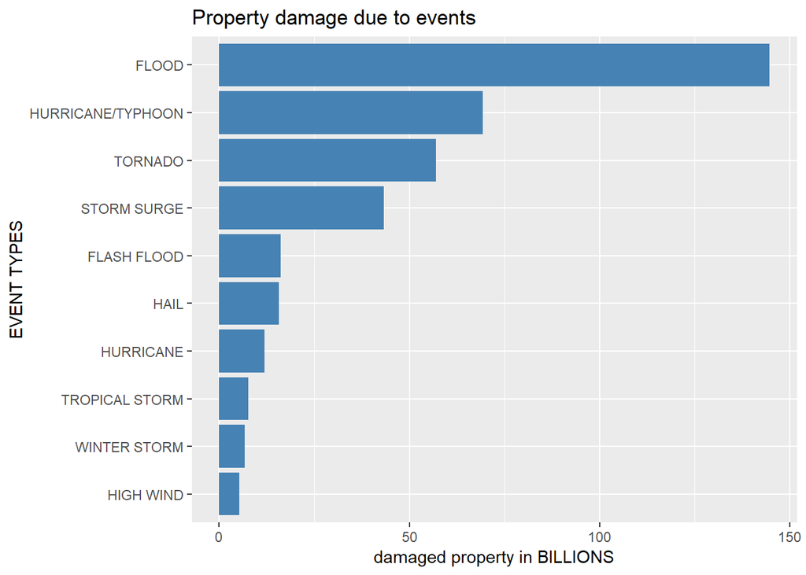

```r
ggplot(head(propfinaldata,n=10),aes(x=reorder(EVTYPE,damaged_property_in_billions),y=damaged_property_in_billions))+geom_bar(fill="steelblue",stat="identity")+coord_flip()+ylab("damaged property in BILLIONS")+xlab("EVENT TYPES")+ggtitle("Property damage due to events")
```

### crop damage due to events

```r
head(cropfinaldata,n=15)
```

```
##                EVTYPE damaged_property_in_dollars damaged_crop_in_dollars
## 95            DROUGHT                  1046106000             13972566000
## 170             FLOOD                144657709807              5661968450
## 590       RIVER FLOOD                  5118945500              5029459000
## 427         ICE STORM                  3944927860              5022113500
## 244              HAIL                 15732267543              3025954473
## 402         HURRICANE                 11868319010              2741910000
## 411 HURRICANE/TYPHOON                 69305840000              2607872800
## 153       FLASH FLOOD                 16140812067              1421317100
## 140      EXTREME COLD                    67737400              1292973000
## 212      FROST/FREEZE                     9480000              1094086000
## 290        HEAVY RAIN                   694248090               733399800
## 848    TROPICAL STORM                  7703890550               678346000
## 359         HIGH WIND                  5270046295               638571300
## 856         TSTM WIND                  4484928495               554007350
```

[output cut: 17 more lines]

### plotting the damaged crop due to events

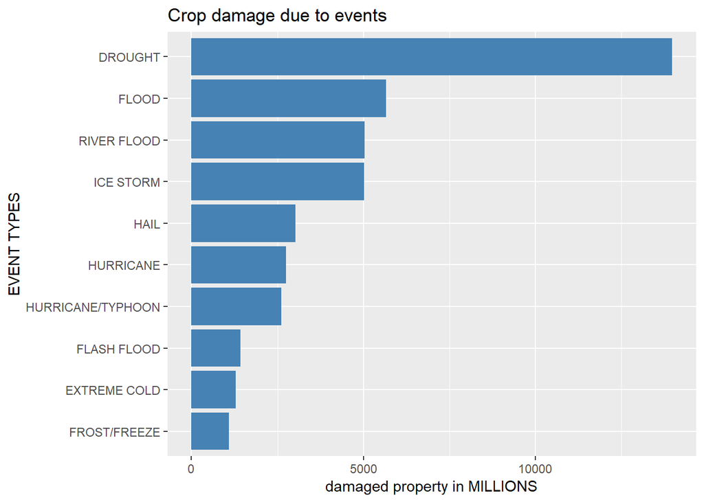

```r
ggplot(head(cropfinaldata,n=10),aes(x=reorder(EVTYPE,damaged_crop_in_millions),y=damaged_crop_in_millions))+geom_bar(fill="steelblue",stat="identity")+coord_flip()+ylab("damaged property in MILLIONS")+xlab("EVENT TYPES")+ggtitle("Crop damage due to events")
```